# Home Credit Default Risk

Megan Beckett

16 July 2018

# Introduction

The purpose of this notebook is to show my approach, exploration and findings for the Kaggle competition being run by Home Credit with the question:

- **Can you predict how capable each applicant is of repaying a loan?**

There are several datasets provided, but in this analysis I have focused on the main application dataset, with some exploration of the Bureau dataset.

This notebook includes my exploratory data analysis (step 00) and the subsequent steps are in R_scripts, with my general approach being:

- **00_explore:** Exploratory data analysis
- **01_preprocess:** Steps I took to clean and preprocess the data
- **02_model:** Training the model (I’ve left a few iterations in to show how it evolved)
- **03_test:** Evaluate model, look at importance of variables and make predictions on test dataset
- **04_submit:** Code for creating Kaggle submission file

# Set up

### Load packages required

Other packages required in subsequent steps are at the top of the relevant R_script.

```r
library(dplyr)
library(readr)
library(ggplot2)
library(tidyr)
library(skimr)
library(DT)
```

#### Read in datasets

These are app_train, app_test and bureau.

```r
app_train <- read_csv("../raw_data/application_train.csv")
app_test <- read_csv("../raw_data/application_test.csv")
bureau <- read_csv("../raw_data/bureau.csv")
app_prev <- read_csv("../raw_data/previous_application.csv")
```

# Overview of dataset

### Summaries

Notes:

- I normally use a combination of str(), summary(), glimpse() to do this and recently explored skim() of which the results are shown here.
- I like how it splits the summary statistics across variable type and shows a basic histogram for numerical types.
- Missing values are also shown and this, along with the histograms, gives some indication of what to explore further.

```r
#str(app_train)
#summary(app_train)
#glimpse(app_train)
skim(app_train)
```

|  | variable | type | stat | level | value | formatted |
| --- | --- | --- | --- | --- | --- | --- |
| 1 | SK_ID_CURR | integer | missing | .all | 0.000000e+00 | 0 |
| 2 | SK_ID_CURR | integer | complete | .all | 3.075110e+05 | 307511 |
| 3 | SK_ID_CURR | integer | n | .all | 3.075110e+05 | 307511 |
| 4 | SK_ID_CURR | integer | mean | .all | 2.781805e+05 | 278180.52 |
| 5 | SK_ID_CURR | integer | sd | .all | 1.027902e+05 | 1e+05 |
| 6 | SK_ID_CURR | integer | p0 | .all | 1.000020e+05 | 1e+05 |
| 7 | SK_ID_CURR | integer | p25 | .all | 1.891455e+05 | 189145.5 |
| 8 | SK_ID_CURR | integer | p50 | .all | 2.782020e+05 | 278202 |
| 9 | SK_ID_CURR | integer | p75 | .all | 3.671425e+05 | 367142.5 |
| 10 | SK_ID_CURR | integer | p100 | .all | 4.562550e+05 | 456255 |

[output cut: 1268 more lines]

### Data types of variables

```r
table(sapply(app_train, class))
```

```
##
## character   integer   numeric
##        16        41        65
```

Notes:

- There are 16 categorical (character) variables to convert to factors.
- If I’d used read.csv, they could be converted automatically to factors, but read_csv is much faster.

# Exploring missing values

### Total missing values

```r
# Total missing values
total_missing = sum(is.na(app_train))
print(c("Total missing values in application train dataset:", total_missing))
```

```
## [1] "Total missing values in application train dataset:"
## [2] "9152465"
```

### Missing values per variable

```r
# Absolute missing values per column
missing_val_abs <- colSums(is.na(app_train))
# Percentage missing values per column
missing_val_per <- missing_val_abs/nrow(app_train)*100
# Get column names
colnames <- colnames(app_train)
# Create dataframe of missing values and display as datatable
missing_summary = subset(data.frame(missing_val_abs, missing_val_per), missing_val_per>0)
missing_summary %>% datatable(filter = 'top', colnames = c('Total missing values', 'Percentage missing values'),
            options = list(pageLength = 15, autoWidth = F, order = list(2, 'desc')))
```

|  | Total missing values | Percentage missing values |
| --- | --- | --- |
| AMT_ANNUITY | 12 | 0.00390229942993909 |
| AMT_GOODS_PRICE | 278 | 0.0904032701269223 |
| NAME_TYPE_SUITE | 1292 | 0.420147571956776 |
| OWN_CAR_AGE | 202929 | 65.9908100848425 |
| OCCUPATION_TYPE | 96391 | 31.3455453626049 |
| CNT_FAM_MEMBERS | 2 | 0.000650383238323182 |
| EXT_SOURCE_1 | 173378 | 56.3810725469983 |
| EXT_SOURCE_2 | 660 | 0.21462646864665 |
| EXT_SOURCE_3 | 60965 | 19.8253070621864 |
| APARTMENTS_AVG | 156061 | 50.7497292779771 |

[output cut: 57 more lines]

Notes:

- There are 67 variables in total with missing values.
- 49 variables have over 40% missing values.
- A large portion of these are to do with the decription of the typeof property.

# Exploration of single variables

## TARGET classification

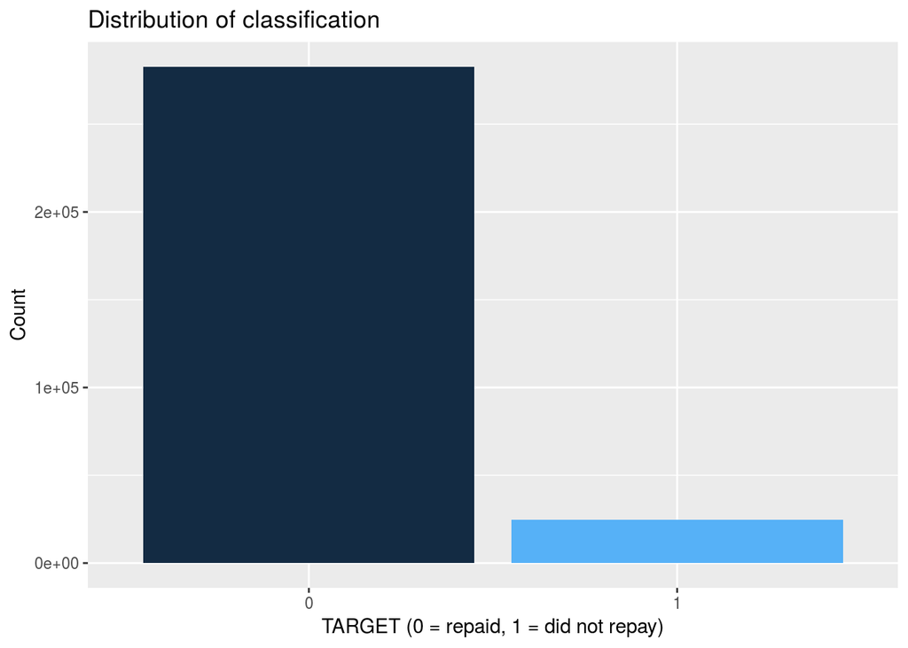

```r
# Target variable - classification
app_train %>%
  count(TARGET) %>%
  arrange(desc(n)) %>%
  ggplot(aes(reorder(TARGET, -n, FUN = min), n, fill = TARGET)) +
  geom_col() +
  theme(legend.position = "none") +
  labs(x = 'TARGET (0 = repaid, 1 = did not repay)',y = 'Count') +
  ggtitle("Distribution of classification")
```

Notes:

- Binary classification (0 if loan repaid, 1 if loan not repaid).
- There are many more loans paid on time than there aren’t.

## Quantitative variable exploration

Notes:

- All of the numerical variables shown here are right skewed.
- This is can be dealt with in preprocessing, but I have left them as is for now.

### Distribution of amount of credit

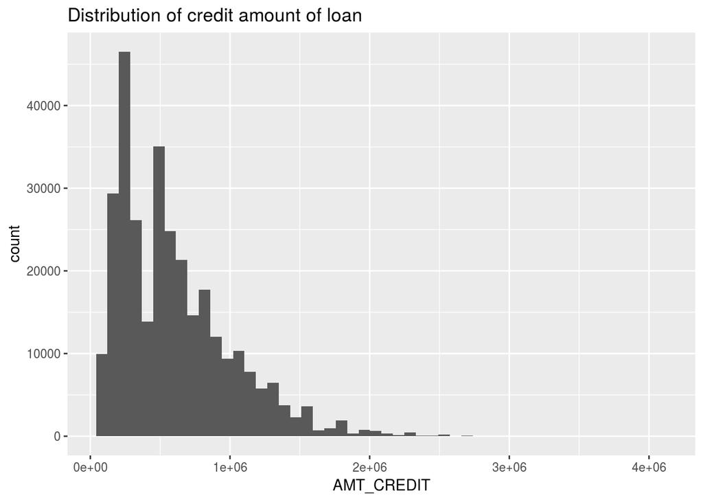

```r
ggplot(app_train, aes(AMT_CREDIT)) +
  geom_histogram(bins = 50) +
  ggtitle("Distribution of credit amount of loan")
```

### Distribution of loan annuity

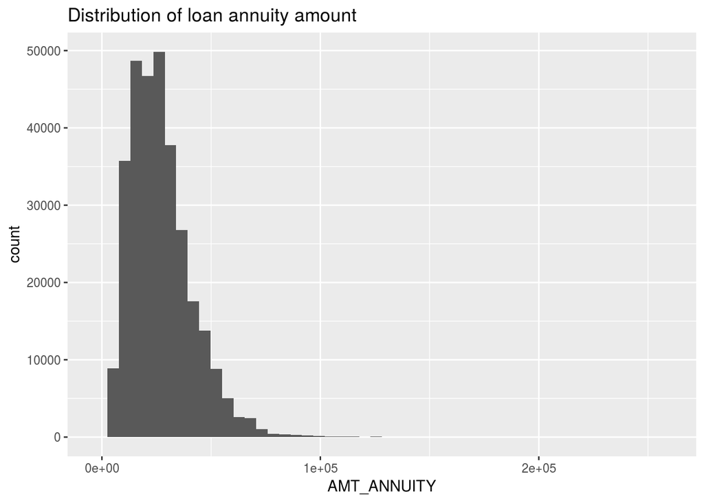

```r
ggplot(app_train, aes(AMT_ANNUITY)) +
  geom_histogram(bins = 50) +
  ggtitle("Distribution of loan annuity amount")
```

### Distribution of goods price

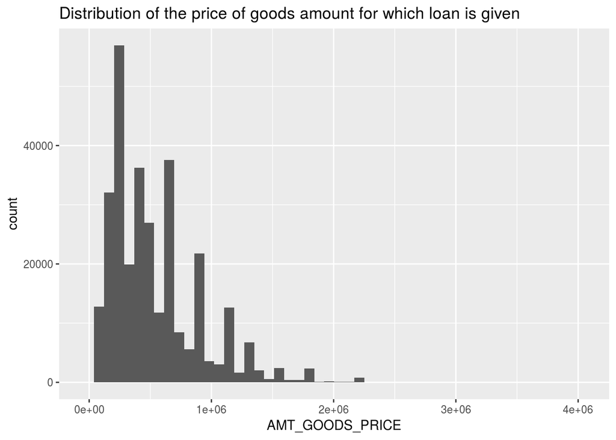

```r
ggplot(app_train, aes(AMT_GOODS_PRICE)) +
  geom_histogram(bins = 50) +
  ggtitle("Distribution of the price of goods amount for which loan is given")
```

### Income distribution

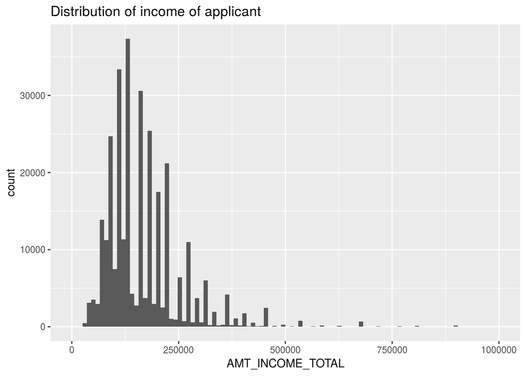

```r
ggplot(app_train, aes(AMT_INCOME_TOTAL)) +
  geom_histogram(bins= 100) +
  xlim(0,1000000) +
  ggtitle("Distribution of income of applicant")
```

Summary of AMT_INCOME_TOTAL for app_train and app_test, respectively:

```r
summary(app_train$AMT_INCOME_TOTAL)
```

```
##      Min.   1st Qu.    Median      Mean   3rd Qu.      Max.
##     25650    112500    147200    168800    202500 117000000
```

```r
summary(app_test$AMT_INCOME_TOTAL)
```

```
##    Min. 1st Qu.  Median    Mean 3rd Qu.    Max.
##   26940  112500  157500  178400  225000 4410000
```

Notes: There is a really large outlier at over $100 000 000 for total income. It seems unlikely that such an individual would be applying for a loan and this could be a mistake.

## Categorical variable exploration

### Type of loan

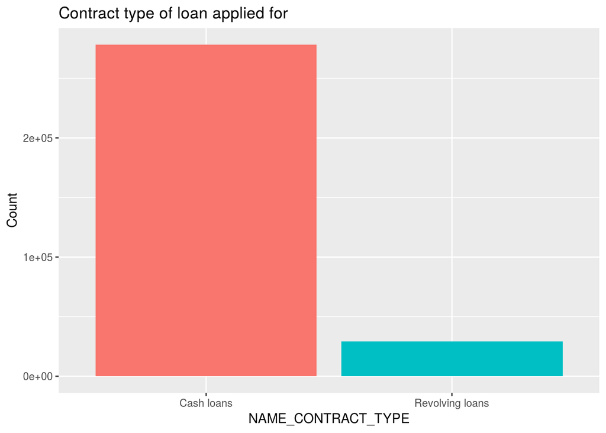

```r
app_train %>%
  count(NAME_CONTRACT_TYPE) %>%
  arrange(desc(n)) %>%
  ggplot(aes(reorder(NAME_CONTRACT_TYPE, -n, FUN = min), n, fill = NAME_CONTRACT_TYPE)) +
  geom_col() +
  theme(legend.position = "none") +
  labs(x = 'NAME_CONTRACT_TYPE',y = 'Count') +
  ggtitle("Contract type of loan applied for")
```

Note: Predominant loan type is cash loan.

### Gender

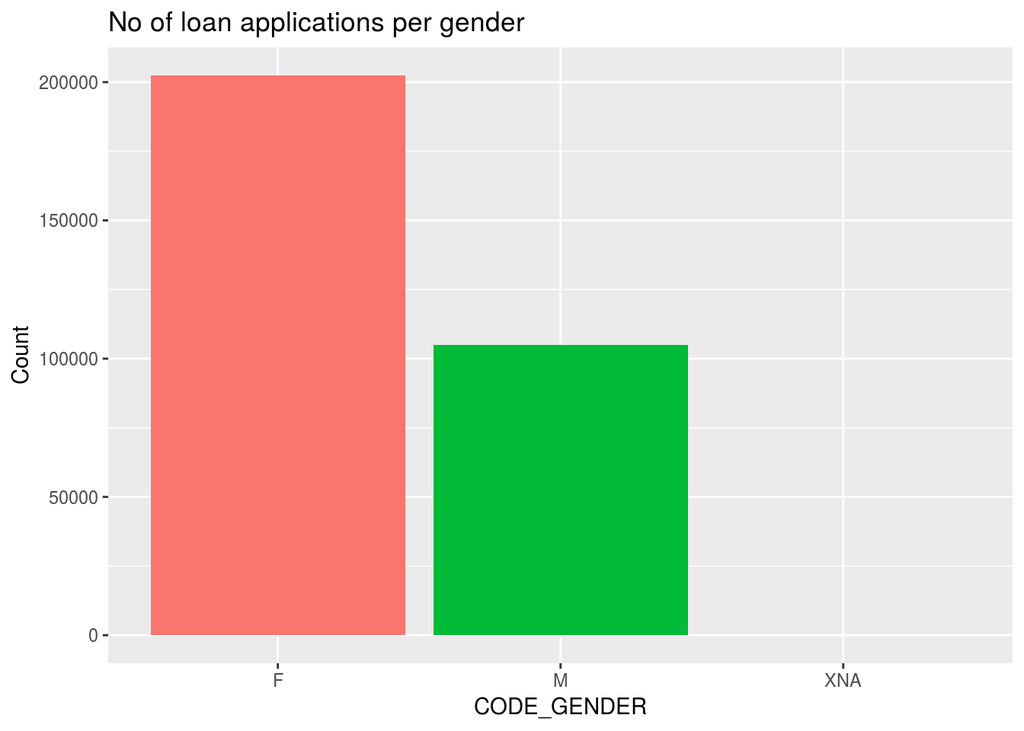

```r
app_train %>%
  count(CODE_GENDER) %>%
  arrange(desc(n)) %>%
  ggplot(aes(reorder(CODE_GENDER, -n, FUN = min), n, fill = CODE_GENDER)) +
  geom_col() +
  theme(legend.position = "none") +
  labs(x = 'CODE_GENDER',y = 'Count') +
  ggtitle("No of loan applications per gender")
```

Note: More females applying for loans than males.

### Own a car

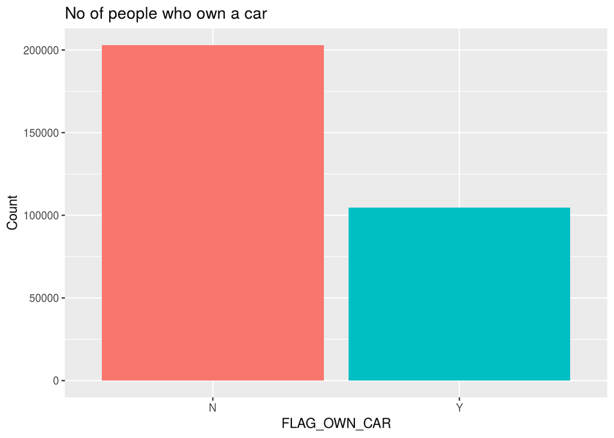

```r
app_train %>%
  count(FLAG_OWN_CAR) %>%
  arrange(desc(n)) %>%
  ggplot(aes(reorder(FLAG_OWN_CAR, -n, FUN = min), n, fill = FLAG_OWN_CAR)) +
  geom_col() +
  theme(legend.position = "none") +
  labs(x = 'FLAG_OWN_CAR',y = 'Count') +
  ggtitle("No of people who own a car")
```

Note: About 50% less people own a car than those who don’t

### Own any property

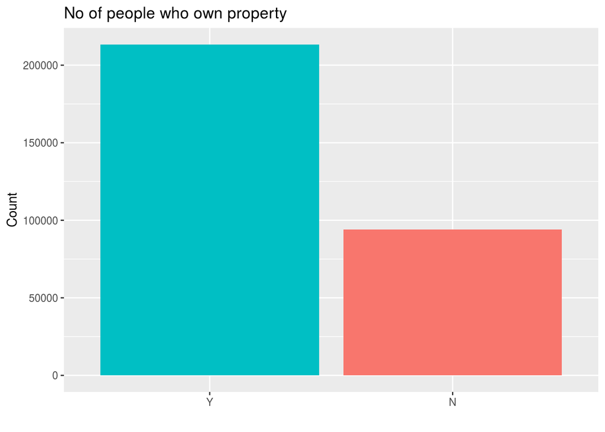

```r
app_train %>%
  count(FLAG_OWN_REALTY) %>%
  arrange(desc(n)) %>%
  ggplot(aes(reorder(FLAG_OWN_REALTY, -n, FUN = min), n, fill = FLAG_OWN_REALTY)) +
  geom_col() +
  theme(legend.position = "none") +
  labs(x = '',y = 'Count') +
  ggtitle("No of people who own property")
```

Note: Unlike owning a car, there are many more who own property

### Level of education of loan applicants

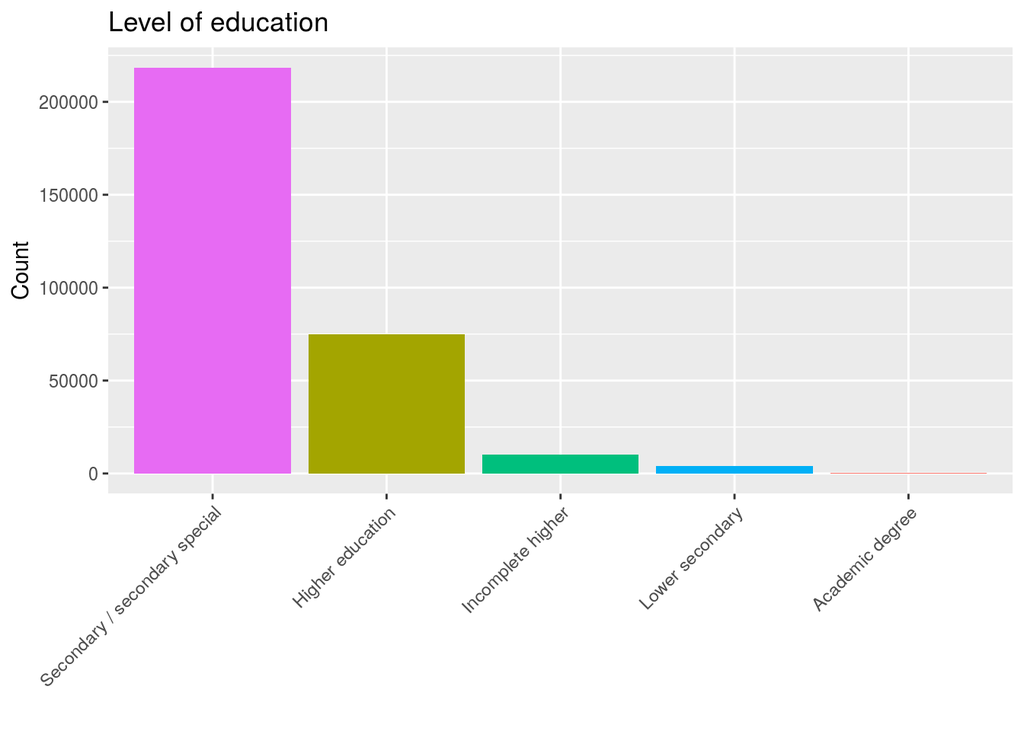

```r
app_train %>%
  count(NAME_EDUCATION_TYPE) %>%
  arrange(desc(n)) %>%
  ggplot(aes(reorder(NAME_EDUCATION_TYPE, -n, FUN = min), n, fill = NAME_EDUCATION_TYPE)) +
  geom_col() +
  theme(legend.position = "none") +
  labs(x = '',y = 'Count') +
  theme(axis.text.x = element_text(angle = 45, hjust=1)) +
  ggtitle("Level of education")
```

Notes: The majority have completed secondary school. There are a few with incomplete highschool or only lower secondary. This is an interesting flag.

### Income level of applicants

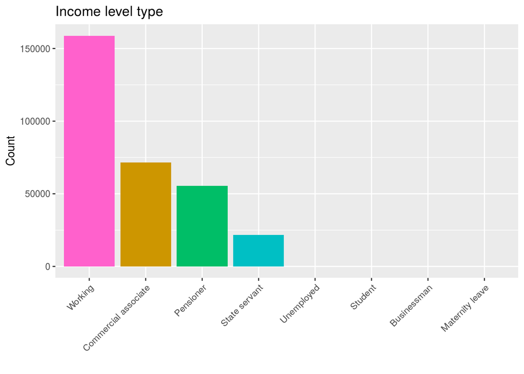

```r
app_train %>%
  count(NAME_INCOME_TYPE) %>%
  arrange(desc(n)) %>%
  ggplot(aes(reorder(NAME_INCOME_TYPE, -n, FUN = min), n, fill = NAME_INCOME_TYPE)) +
  geom_col() +
  theme(legend.position = "none") +
  labs(x = '',y = 'Count') +
  theme(axis.text.x = element_text(angle = 45, hjust=1)) +
  ggtitle("Income level type")
```

Notes: The majority are working. There is a significant portion of pensioners, which is interesting. There are also some unemployed, students and those on materynity leave.

# Exploration of variables measuring time/age

## Age of clients

```r
summary(app_train$DAYS_BIRTH)
```

```
##    Min. 1st Qu.  Median    Mean 3rd Qu.    Max.
##  -25230  -19680  -15750  -16040  -12410   -7489
```

Notes:

- Interesting, these are negative numbers.
- According to Home Credit, these numbers indicate the relative age of person in number of days backwards from loan application date.

Convert numbers to absolute value and in years to view a meaningful plot.

```r
age = as.data.frame(app_train$DAYS_BIRTH/(-365))
colnames(age) = 'AGE_YEARS'
summary(age)
```

```
##    AGE_YEARS
##  Min.   :20.52
##  1st Qu.:34.01
##  Median :43.15
##  Mean   :43.94
##  3rd Qu.:53.92
##  Max.   :69.12
```

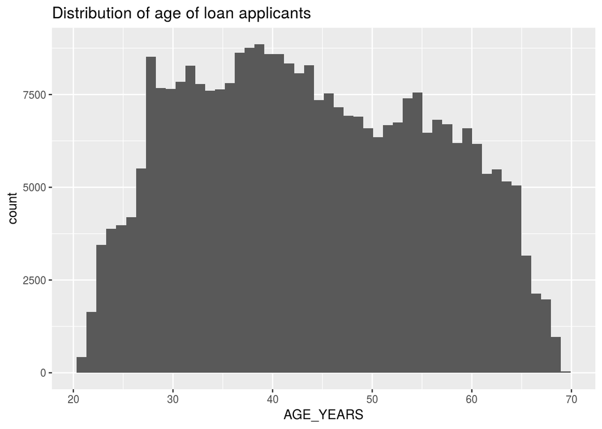

```r
ggplot(age, aes(AGE_YEARS)) +
  geom_histogram(bins = 50) +
  ggtitle("Distribution of age of loan applicants")
```

Notes: Median age is in the 40’s and there is a wide distribution in ages from 20 to 70 years old.

# Days of employment

```r
summary(app_train$DAYS_EMPLOYED)
```

```
##    Min. 1st Qu.  Median    Mean 3rd Qu.    Max.
##  -17910   -2760   -1213   63820    -289  365200
```

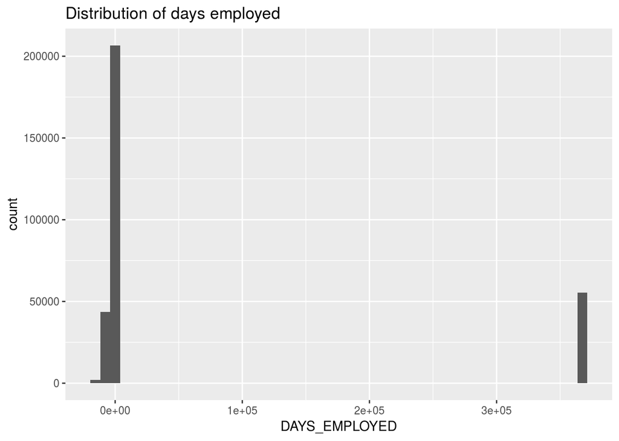

```r
ggplot(app_train, aes(DAYS_EMPLOYED)) +
  geom_histogram(bins = 50) +
  ggtitle("Distribution of days employed")
```

Notes:

- As with age in number of days, days of emplyment is no days before the application the person started current employment.
- Median is -1213 which is about 3 years prior to application.
- But, positive numbers don’t make sense and there are massive outliers equating to about 1000 years (365243 days)

Create subset of these outliers to investigate.

```r
employed_outliers <- subset(app_train, DAYS_EMPLOYED > 0)
employed_normal <- subset(app_train, DAYS_EMPLOYED <= 0)
print("Summary of outliers TARGET")
```

```
## [1] "Summary of outliers TARGET"
```

```r
summary(employed_outliers$TARGET)
```

```
##    Min. 1st Qu.  Median    Mean 3rd Qu.    Max.
##   0.000   0.000   0.000   0.054   0.000   1.000
```

```r
print("Summary of normal TARGET")
```

```
## [1] "Summary of normal TARGET"
```

```r
summary(employed_normal$TARGET)
```

```
##    Min. 1st Qu.  Median    Mean 3rd Qu.    Max.
##  0.0000  0.0000  0.0000  0.0866  0.0000  1.0000
```

Notes:

- The outliers (all have same value of 365243 days) only default on 5.4% of loans whereas those with reasonable employment records, don’t repay 8.66% of time.
- Investigate later by replacing these values with NA before imputation to replace missing values and see if has an effect.

# A quick look at additional datasets

## Bureau

```r
summary(bureau)
```

```
##    SK_ID_CURR      SK_ID_BUREAU     CREDIT_ACTIVE      CREDIT_CURRENCY
##  Min.   :100001   Min.   :5000000   Length:1716428     Length:1716428
##  1st Qu.:188867   1st Qu.:5463954   Class :character   Class :character
##  Median :278055   Median :5926304   Mode  :character   Mode  :character
##  Mean   :278215   Mean   :5924434
##  3rd Qu.:367426   3rd Qu.:6385681
##  Max.   :456255   Max.   :6843457
##
##   DAYS_CREDIT    CREDIT_DAY_OVERDUE  DAYS_CREDIT_ENDDATE DAYS_ENDDATE_FACT
##  Min.   :-2922   Min.   :   0.0000   Min.   :-42060.0    Min.   :-42023
##  1st Qu.:-1666   1st Qu.:   0.0000   1st Qu.: -1138.0    1st Qu.: -1489
##  Median : -987   Median :   0.0000   Median :  -330.0    Median :  -897
##  Mean   :-1142   Mean   :   0.8182   Mean   :   510.5    Mean   : -1017
##  3rd Qu.: -474   3rd Qu.:   0.0000   3rd Qu.:   474.0    3rd Qu.:  -425
##  Max.   :    0   Max.   :2792.0000   Max.   : 31199.0    Max.   :     0
##                                      NA's   :105553      NA's   :633653
##  AMT_CREDIT_MAX_OVERDUE CNT_CREDIT_PROLONG AMT_CREDIT_SUM
##  Min.   :        0      Min.   :0.00000    Min.   :        0
##  1st Qu.:        0      1st Qu.:0.00000    1st Qu.:    51300
##  Median :        0      Median :0.00000    Median :   125518
##  Mean   :     3825      Mean   :0.00641    Mean   :   354995
##  3rd Qu.:        0      3rd Qu.:0.00000    3rd Qu.:   315000
##  Max.   :115987185      Max.   :9.00000    Max.   :585000000
##  NA's   :1124488                           NA's   :13
##  AMT_CREDIT_SUM_DEBT AMT_CREDIT_SUM_LIMIT AMT_CREDIT_SUM_OVERDUE
##  Min.   : -4705600   Min.   :-586406      Min.   :      0
##  1st Qu.:        0   1st Qu.:      0      1st Qu.:      0
##  Median :        0   Median :      0      Median :      0
##  Mean   :   137085   Mean   :   6230      Mean   :     38
##  3rd Qu.:    40154   3rd Qu.:      0      3rd Qu.:      0
##  Max.   :170100000   Max.   :4705600      Max.   :3756681
##  NA's   :257669      NA's   :591780
##  CREDIT_TYPE        DAYS_CREDIT_UPDATE  AMT_ANNUITY
##  Length:1716428     Min.   :-41947.0   Min.   :        0
##  Class :character   1st Qu.:  -908.0   1st Qu.:        0
##  Mode  :character   Median :  -395.0   Median :        0
##                     Mean   :  -593.8   Mean   :    15713
##                     3rd Qu.:   -33.0   3rd Qu.:    13500
##                     Max.   :   372.0   Max.   :118453424
##                                        NA's   :1226791
```

```r
skim(bureau)
```

|  | variable | type | stat | level | value | formatted |
| --- | --- | --- | --- | --- | --- | --- |
| 1 | SK_ID_CURR | integer | missing | .all | 0.000000e+00 | 0 |
| 2 | SK_ID_CURR | integer | complete | .all | 1.716428e+06 | 1716428 |
| 3 | SK_ID_CURR | integer | n | .all | 1.716428e+06 | 1716428 |
| 4 | SK_ID_CURR | integer | mean | .all | 2.782149e+05 | 278214.93 |
| 5 | SK_ID_CURR | integer | sd | .all | 1.029386e+05 | 1e+05 |
| 6 | SK_ID_CURR | integer | p0 | .all | 1.000010e+05 | 1e+05 |
| 7 | SK_ID_CURR | integer | p25 | .all | 1.888668e+05 | 188866.75 |
| 8 | SK_ID_CURR | integer | p50 | .all | 2.780550e+05 | 278055 |
| 9 | SK_ID_CURR | integer | p75 | .all | 3.674260e+05 | 367426 |
| 10 | SK_ID_CURR | integer | p100 | .all | 4.562550e+05 | 456255 |

[output cut: 165 more lines]

What are the unique values for the variable CREDIT_ACTIVE?

```r
unique(bureau$CREDIT_ACTIVE)
```

```
## [1] "Closed"   "Active"   "Sold"     "Bad debt"
```

## Previous application

```r
summary(app_prev)
```

```
##    SK_ID_PREV        SK_ID_CURR     NAME_CONTRACT_TYPE  AMT_ANNUITY
##  Min.   :1000001   Min.   :100001   Length:1670214     Min.   :     0
##  1st Qu.:1461857   1st Qu.:189329   Class :character   1st Qu.:  6322
##  Median :1923110   Median :278714   Mode  :character   Median : 11250
##  Mean   :1923089   Mean   :278357                      Mean   : 15955
##  3rd Qu.:2384280   3rd Qu.:367514                      3rd Qu.: 20658
##  Max.   :2845382   Max.   :456255                      Max.   :418058
##                                                        NA's   :372235
##  AMT_APPLICATION     AMT_CREDIT      AMT_DOWN_PAYMENT    AMT_GOODS_PRICE
##  Min.   :      0   Min.   :      0   Min.   :     -0.9   Min.   :      0
##  1st Qu.:  18720   1st Qu.:  24160   1st Qu.:      0.0   1st Qu.:  50841
##  Median :  71046   Median :  80541   Median :   1638.0   Median : 112320
##  Mean   : 175234   Mean   : 196114   Mean   :   6697.4   Mean   : 227847
##  3rd Qu.: 180360   3rd Qu.: 216418   3rd Qu.:   7740.0   3rd Qu.: 234000
##  Max.   :6905160   Max.   :6905160   Max.   :3060045.0   Max.   :6905160
##                    NA's   :1         NA's   :895844      NA's   :385515
##  WEEKDAY_APPR_PROCESS_START HOUR_APPR_PROCESS_START
##  Length:1670214             Min.   : 0.00
##  Class :character           1st Qu.:10.00
##  Mode  :character           Median :12.00
##                             Mean   :12.48
##                             3rd Qu.:15.00
##                             Max.   :23.00
##
##  FLAG_LAST_APPL_PER_CONTRACT NFLAG_LAST_APPL_IN_DAY RATE_DOWN_PAYMENT
##  Length:1670214              Min.   :0.0000         Min.   :0.0
##  Class :character            1st Qu.:1.0000         1st Qu.:0.0
##  Mode  :character            Median :1.0000         Median :0.1
##                              Mean   :0.9965         Mean   :0.1
##                              3rd Qu.:1.0000         3rd Qu.:0.1
##                              Max.   :1.0000         Max.   :1.0
##                                                     NA's   :895844
##  RATE_INTEREST_PRIMARY RATE_INTEREST_PRIVILEGED NAME_CASH_LOAN_PURPOSE
##  Min.   :0.0           Min.   :0.4              Length:1670214
##  1st Qu.:0.2           1st Qu.:0.7              Class :character
##  Median :0.2           Median :0.8              Mode  :character
##  Mean   :0.2           Mean   :0.8
##  3rd Qu.:0.2           3rd Qu.:0.9
##  Max.   :1.0           Max.   :1.0
##  NA's   :1664263       NA's   :1664263
```

[output cut: 41 more lines]

```
##  Min.   : -2922     Min.   : -2892   Min.   : -2801
##  1st Qu.:365243     1st Qu.: -1628   1st Qu.: -1242
##  Median :365243     Median :  -831   Median :  -361
##  Mean   :342210     Mean   : 13826   Mean   : 33768
##  3rd Qu.:365243     3rd Qu.:  -411   3rd Qu.:   129
##  Max.   :365243     Max.   :365243   Max.   :365243
##  NA's   :673065     NA's   :673065   NA's   :673065
##  DAYS_LAST_DUE    DAYS_TERMINATION NFLAG_INSURED_ON_APPROVAL
##  Min.   : -2889   Min.   : -2874   Min.   :0.0
##  1st Qu.: -1314   1st Qu.: -1270   1st Qu.:0.0
##  Median :  -537   Median :  -499   Median :0.0
##  Mean   : 76582   Mean   : 81992   Mean   :0.3
##  3rd Qu.:   -74   3rd Qu.:   -44   3rd Qu.:1.0
##  Max.   :365243   Max.   :365243   Max.   :1.0
##  NA's   :673065   NA's   :673065   NA's   :673065
```

What are the unique values for the variables CODE_REJECT_REASON and NAME_CONTRACT_STATUS, respectively?

```r
unique(app_prev$CODE_REJECT_REASON)
```

```
## [1] "XAP"    "HC"     "LIMIT"  "CLIENT" "SCOFR"  "SCO"    "XNA"    "VERIF"
## [9] "SYSTEM"
```

```r
unique(app_prev$NAME_CONTRACT_STATUS)
```

```
## [1] "Approved"     "Refused"      "Canceled"     "Unused offer"
```